# individual_assignment

## 1. Create the following dataset (1 point)

- One column per stock and concept: Open, High, Low, Close, Adj close per stock
- Date as index

Be ready for dealing with errors in the names and some missing values.

```python
# importing all basic needs

import pandas as pd
import numpy as np
import matplotlib.pyplot as plt
import numpy as np
import datetime as datetime

# reading the csv
stox = pd.read_csv("stocks_unclean.csv")

stox["date"] = pd.to_datetime(stox["date"])

#getting unique values to check out column names
uniqueValues = stox['variable'].unique()
uniqueValues
```

```
array(['high_AAPL', 'volume_AMZN', 'volume_MSFT', 'low_GOOG', 'open_AMZN',
       'volume_AAPL', 'open_MSFT', 'open_AAPL', 'close_GOOG', 'low_AMZN',
       'close_AAPL', 'volume_GOOG', 'open_GOOG', 'high_AMZN', 'low_AAPL',
       'low_MSFT', 'high_MSFT', 'high_GOOG', 'close_AMZN', 'close_MSFT',
       nan], dtype=object)
```

```python
# I decided to create different subsets of the original df
# I think this will make it easier to deal with null values
# each df maybe has null values that need to be handled differently
    #maybe volume and adj close have different needs in terms of null values for ex...
```

```python
#setting some conditions to slice the df

#GOOGLE
close_GOOG = stox[(stox["variable"] == "close_GOOG")]
open_GOOG = stox[(stox["variable"] == "open_GOOG")]
volume_GOOG = stox[(stox["variable"] == "volume_GOOG")]
low_GOOG = stox[(stox["variable"] == "low_GOOG")]
high_GOOG = stox[(stox["variable"] == "high_GOOG")]

    #setting a usable column name for each subset of data
close_GOOG.columns= close_GOOG.columns.str.lower().str.replace("value","adj close GOOG")
open_GOOG.columns= open_GOOG.columns.str.lower().str.replace("value","open GOOG")
volume_GOOG.columns= volume_GOOG.columns.str.lower().str.replace("value","volume GOOG")
low_GOOG.columns= low_GOOG.columns.str.lower().str.replace("value","low GOOG")
high_GOOG.columns= high_GOOG.columns.str.lower().str.replace("value","high GOOG")


#AMAZON
close_AMZN = stox[(stox["variable"] == "close_AMZN")]
open_AMZN = stox[(stox["variable"] == "open_AMZN")]
volume_AMZN = stox[(stox["variable"] == "volume_AMZN")]
low_AMZN = stox[(stox["variable"] == "low_AMZN")]
high_AMZN = stox[(stox["variable"] == "high_AMZN")]

    #setting a usable column name
close_AMZN.columns= close_AMZN.columns.str.lower().str.replace("value","adj close AMZN")
open_AMZN.columns= open_AMZN.columns.str.lower().str.replace("value","open AMZN")
volume_AMZN.columns= volume_AMZN.columns.str.lower().str.replace("value","volume AMZN")
low_AMZN.columns= low_AMZN.columns.str.lower().str.replace("value","low AMZN")
high_AMZN.columns= high_AMZN.columns.str.lower().str.replace("value","high AMZN")

#APPLE
close_AAPL = stox[(stox["variable"] == "close_AAPL")]
open_AAPL = stox[(stox["variable"] == "open_AAPL")]
volume_AAPL = stox[(stox["variable"] == "volume_AAPL")]
low_AAPL = stox[(stox["variable"] == "low_AAPL")]
high_AAPL = stox[(stox["variable"] == "high_AAPL")]

    #setting a usable column name
close_AAPL.columns= close_AAPL.columns.str.lower().str.replace("value","adj close AAPL")
open_AAPL.columns= open_AAPL.columns.str.lower().str.replace("value","open AAPL")
volume_AAPL.columns= volume_AAPL.columns.str.lower().str.replace("value","volume AAPL")
low_AAPL.columns = low_AAPL.columns.str.lower().str.replace("value","low AAPL")
high_AAPL.columns= high_AAPL.columns.str.lower().str.replace("value","high AAPL")

#MSFT
close_MSFT = stox[(stox["variable"] == "close_MSFT")]
open_MSFT = stox[(stox["variable"] == "open_MSFT")]
volume_MSFT = stox[(stox["variable"] == "volume_MSFT")]
low_MSFT = stox[(stox["variable"] == "low_MSFT")]
high_MSFT = stox[(stox["variable"] == "high_MSFT")]

    #setting a usable column name
close_MSFT.columns= close_MSFT.columns.str.lower().str.replace("value","adj close MSFT")
open_MSFT.columns= open_MSFT.columns.str.lower().str.replace("value","open MSFT")
volume_MSFT.columns= volume_MSFT.columns.str.lower().str.replace("value","volume MSFT")
low_MSFT.columns = low_MSFT.columns.str.lower().str.replace("value","low MSFT")
high_MSFT.columns= high_MSFT.columns.str.lower().str.replace("value","high MSFT")
```

```python
#merging the dfs for each stock and dropping columns I don't want
GOOG_temp = open_GOOG.merge(
    close_GOOG,on='date').merge(
    low_GOOG,on='date').merge(
    high_GOOG,on='date').merge(
    volume_GOOG, on='date').drop(
    columns=['variable_x',
             'variable_y',
             'variable'])

AMZN_temp = open_AMZN.merge(
    close_AMZN,on='date').merge(
    low_AMZN,on='date').merge(
    high_AMZN,on='date').merge(
    volume_AMZN, on='date').drop(
    columns=['variable_x',
             'variable_y',
             'variable'])

AAPL_temp = open_AAPL.merge(
    close_AAPL,on='date').merge(
    low_AAPL,on='date').merge(
    high_AAPL,on='date').merge(
    volume_AAPL, on='date').drop(
    columns=['variable_x',
             'variable_y',
             'variable'])

MSFT_temp = open_MSFT.merge(
    close_MSFT,on='date').merge(
    low_MSFT,on='date').merge(
    high_MSFT,on='date').merge(
    volume_MSFT, on='date').drop(
    columns=['variable_x',
             'variable_y',
             'variable'])

# merging each df from each stock into one and setting date as index
stox_complete = GOOG_temp.merge(
    AMZN_temp,on='date').merge(
    AAPL_temp,on='date').merge(
    MSFT_temp,on='date').set_index(['date'])

stox_complete.head() #checking to see if everything is ok
```

| date | open GOOG | adj close GOOG | low GOOG | high GOOG | volume GOOG | open AMZN | adj close AMZN | low AMZN | high AMZN | volume AMZN | open AAPL | adj close AAPL | low AAPL | high AAPL | volume AAPL | open MSFT | adj close MSFT | low MSFT | high MSFT | volume MSFT |
| --- | --- | --- | --- | --- | --- | --- | --- | --- | --- | --- | --- | --- | --- | --- | --- | --- | --- | --- | --- | --- |
| 2021-06-25 | 2539.139893 | 2539.899902 | 2528.879883 | 2550.100098 | 1674200.0 | 3464.000000 | 3401.459961 | 3394.179932 | 3464.820068 | 3941000.0 | 133.460007 | 133.110001 | 132.809998 | 133.889999 | 70783700.0 | 266.230011 | 265.019989 | 264.760010 | 267.250000 | 25611100.0 |
| 2021-07-07 | 2606.820068 | 2601.550049 | 2595.199951 | 2612.798096 | 834000.0 | 3717.379883 | 3696.580078 | 3678.909912 | 3734.199951 | 5328100.0 | 143.539993 | 144.570007 | 142.660004 | 144.889999 | 104911600.0 | 279.399994 | 279.929993 | 277.149994 | 280.690002 | 23260000.0 |
| 2020-06-16 | 1445.219971 | 1442.719971 | 1425.900024 | 1455.020020 | 1709200.0 | 2620.000000 | 2615.270020 | 2576.000000 | 2620.000000 | 3585600.0 | 87.864998 | 88.019997 | 86.180000 | 88.300003 | 165428800.0 | 192.889999 | 193.570007 | 191.460007 | 195.580002 | 42556700.0 |
| 2021-12-07 | 2919.000000 | 2960.729980 | 2914.050049 | 2966.000000 | 1162900.0 | 3492.000000 | 3523.290039 | 3466.689941 | 3549.989990 | 3320500.0 | 169.080002 | 171.179993 | 168.339996 | 171.580002 | 120405400.0 | 331.640015 | 334.920013 | 330.100006 | 335.799988 | 31021900.0 |
| 2020-08-21 | 1577.030029 | 1580.420044 | 1568.005005 | 1597.719971 | 1446500.0 | 3295.000000 | 3284.719971 | 3275.389893 | 3314.399902 | 3575900.0 | 119.262497 | 124.370003 | 119.250000 | 124.867500 | 338054800.0 | 213.860001 | 213.020004 | 212.850006 | 216.250000 | 36249300.0 |

```python
# now let's dive into null values and see what I can do about them

#checking the distribution of null values
stox_complete.columns.isna().sum()
```

```
0
```

```python
#replacing missing values from the volume columns with the mean using for loops

for column in stox_complete[['volume GOOG', 'volume AMZN', 'volume MSFT', 'volume AAPL']]:
    stox_complete[column].fillna(
    value=stox_complete[column].mean(), inplace=True)

    # why not replace null price values with the mean?
    # because we could be underestimating price volatility

    # the way to go? linear interpolation
    # why?  linear interpolation is appropiate for variables with low volatility

#since we already dealt with the volume columns we can iterate through all columns related to prices

for column in stox_complete.columns:
    stox_complete[column].interpolate(method='linear',
                          axis=0,
                          limit=None,
                          inplace=True)
```

```python
# checking if null values in volume columns got actually replaced
stox_complete.isnull().sum()
```

```
open GOOG         0
adj close GOOG    0
low GOOG          0
high GOOG         0
volume GOOG       0
open AMZN         0
adj close AMZN    0
low AMZN          0
high AMZN         0
volume AMZN       0
open AAPL         0
adj close AAPL    0
low AAPL          0
high AAPL         0
volume AAPL       0
open MSFT         0
adj close MSFT    0
low MSFT          0
high MSFT         0
volume MSFT       0
dtype: int64
```

## 2. Visualize the data (1.5 point)

- Create a 2x2 grid of plots in which you plot the "Open" in green and "Close" in red for each stock (0.5 points)
- Repeat the 2x2 grid but resampling with the weekly average of "Open" and "Close" (0.5 points)
- Add meaningful visualizations of your choice (0.5 point)

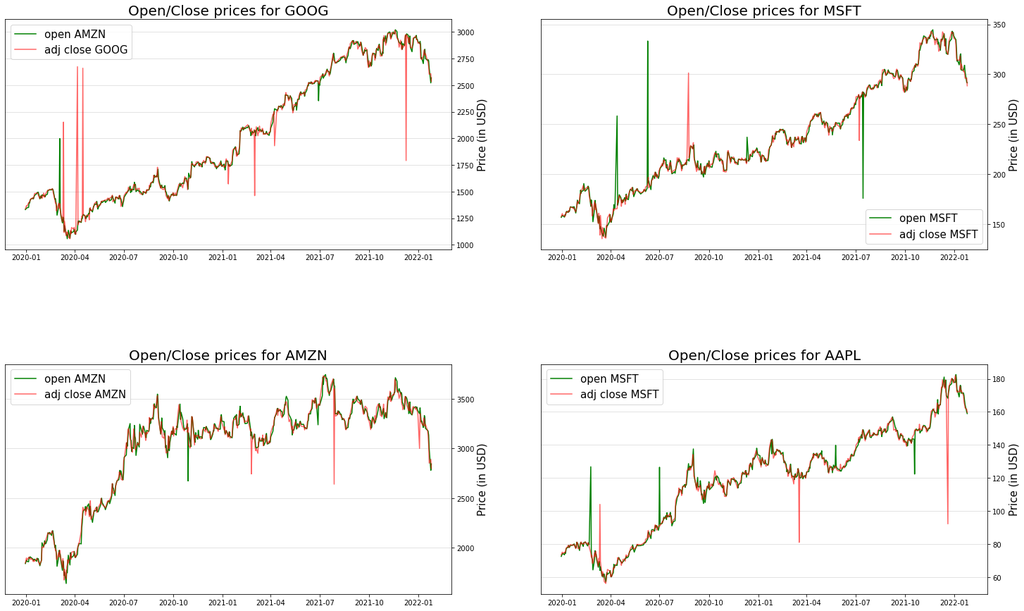

```python
# sorting prices by date in ascending order
stox_complete_sorted = stox_complete.sort_index(ascending=True)

#plotting open/close timeseries

fig, axes = plt.subplots(2, 2, figsize=(25, 15))
plt.subplots_adjust(hspace=0.5)

#GOOG
axes[0, 0].plot(stox_complete_sorted['open GOOG'].index, stox_complete_sorted['open GOOG'],
                label = 'open AMZN',
                color='g')
axes[0, 0].plot(stox_complete_sorted['adj close GOOG'].index, stox_complete_sorted['adj close GOOG'],
                label="adj close GOOG", color='r', alpha=0.6)
axes[0, 0].yaxis.tick_right()
axes[0, 0].set_ylabel('Price (in USD)', fontsize=15)
axes[0, 0].yaxis.set_label_position("right")
axes[0, 0].grid(axis='y', color='gainsboro')
axes[0, 0].set_title("Open/Close prices for GOOG", fontsize = 20)
axes[0, 0].legend(fontsize=15)

#AMZN
axes[1, 0].plot(stox_complete_sorted['open AMZN'].index, stox_complete_sorted['open AMZN'],
                label = 'open AMZN', color='g')
axes[1, 0].plot(stox_complete_sorted['adj close AMZN'].index, stox_complete_sorted['adj close AMZN'],
                label="adj close AMZN", color='r', alpha=0.6)
axes[1, 0].yaxis.tick_right()
axes[1, 0].set_ylabel('Price (in USD)', fontsize=15)
axes[1, 0].yaxis.set_label_position("right")
axes[1, 0].grid(axis='y', color='gainsboro')
axes[1, 0].set_title("Open/Close prices for AMZN", fontsize = 20)
axes[1, 0].legend(fontsize=15)


#MSFT
axes[0, 1].plot(stox_complete_sorted['open MSFT'].index, stox_complete_sorted['open MSFT'],
                label = 'open MSFT', color='g')
axes[0, 1].plot(stox_complete_sorted['adj close MSFT'].index, stox_complete_sorted['adj close MSFT'],
                label="adj close MSFT", color='r', alpha=0.6)
axes[0, 1].yaxis.tick_right()
axes[0, 1].set_ylabel('Price (in USD)', fontsize=15)
axes[0, 1].yaxis.set_label_position("right")
axes[0, 1].grid(axis='y', color='gainsboro')
axes[0, 1].set_title("Open/Close prices for MSFT", fontsize = 20)
axes[0, 1].legend(fontsize=15)


#AAPL
axes[1, 1].plot(stox_complete_sorted['open AAPL'].index, stox_complete_sorted['open AAPL'],
                label = 'open MSFT', color='g')
axes[1, 1].plot(stox_complete_sorted['adj close AAPL'].index, stox_complete_sorted['adj close AAPL'],
                label="adj close MSFT", color='r', alpha=0.6)
axes[1, 1].yaxis.tick_right()
axes[1, 1].set_title("Open/Close prices for AAPL", fontsize = 20)
axes[1, 1].set_ylabel('Price (in USD)', fontsize=15)
axes[1, 1].yaxis.set_label_position("right")
axes[1, 1].grid(axis='y', color='gainsboro')
axes[1, 1].legend(fontsize=15)
```

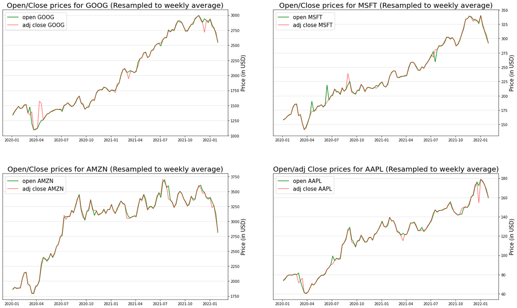

```python
#resampling the open/close prices to weekly avg
#GOOG
open_GOOG_resample_weekly_avg = stox_complete_sorted['open GOOG'].resample("W").mean()
adj_close_GOOG_resample_weekly_avg = stox_complete_sorted['adj close GOOG'].resample("W").mean()

#AMZN
open_AMZN_resample_weekly_avg = stox_complete_sorted['open AMZN'].resample("W").mean()
adj_close_AMZN_resample_weekly_avg = stox_complete_sorted['adj close AMZN'].resample("W").mean()

#MSFT
open_MSFT_resample_weekly_avg = stox_complete_sorted['open MSFT'].resample("W").mean()
adj_close_MSFT_resample_weekly_avg = stox_complete_sorted['adj close MSFT'].resample("W").mean()

#AAPL
open_AAPL_resample_weekly_avg = stox_complete_sorted['open AAPL'].resample("W").mean()
adj_close_AAPL_resample_weekly_avg = stox_complete_sorted['adj close AAPL'].resample("W").mean()



#creating the plots

fig, axes = plt.subplots(2, 2, figsize=(25, 15))
plt.subplots_adjust(hspace=0.3)

#GOOG
axes[0, 0].plot(open_GOOG_resample_weekly_avg.index,
                open_GOOG_resample_weekly_avg,
                label="open GOOG", color='g')
axes[0, 0].plot(adj_close_GOOG_resample_weekly_avg.index,
                adj_close_GOOG_resample_weekly_avg,
                label="adj close GOOG", color = 'r', alpha = 0.6)
axes[0, 0].yaxis.tick_right()
axes[0, 0].set_ylabel('Price (in USD)', fontsize=15)
axes[0, 0].yaxis.set_label_position("right")
axes[0, 0].set_title("Open/Close prices for GOOG (Resampled to weekly average)", fontsize = 20)
axes[0, 0].grid(axis='y', color='gainsboro')
axes[0, 0].legend(fontsize=15)


#AMZN
axes[1, 0].plot(open_AMZN_resample_weekly_avg.index,
                open_AMZN_resample_weekly_avg,
                label = 'open AMZN',
                color='g')
axes[1, 0].plot(adj_close_AMZN_resample_weekly_avg.index,
                adj_close_AMZN_resample_weekly_avg,
                label="adj close AMZN", color='r', alpha=0.6)
axes[1, 0].yaxis.tick_right()
axes[1, 0].set_ylabel('Price (in USD)', fontsize=15)
axes[1, 0].yaxis.set_label_position("right")
axes[1, 0].set_title("Open/Close prices for AMZN (Resampled to weekly average)", fontsize = 20)
axes[1, 0].grid(axis='y', color='gainsboro')
axes[1, 0].legend(fontsize=15)


#MSFT
axes[0, 1].plot(open_MSFT_resample_weekly_avg.index,
                open_MSFT_resample_weekly_avg,
                label = 'open MSFT',
                color='g')
axes[0, 1].plot(adj_close_MSFT_resample_weekly_avg.index,
                adj_close_MSFT_resample_weekly_avg,
                label = 'adj close MSFT', color='r', alpha = 0.6)
axes[0, 1].yaxis.tick_right()
axes[0, 1].set_ylabel('Price (in USD)', fontsize=15)
axes[0, 1].yaxis.set_label_position("right")
axes[0, 1].set_title("Open/Close prices for MSFT (Resampled to weekly average)", fontsize = 20)
axes[0, 1].grid(axis='y', color='gainsboro')
axes[0, 1].legend(fontsize=15)


#AAPL
axes[1, 1].plot(open_AAPL_resample_weekly_avg.index, open_AAPL_resample_weekly_avg,
                label = 'open AAPL', color = 'g')
axes[1, 1].plot(adj_close_AAPL_resample_weekly_avg.index,
                adj_close_AAPL_resample_weekly_avg,
                label = 'adj close AAPL', color = 'r', alpha = 0.6)
axes[1, 1].yaxis.tick_right()
axes[1, 1].set_ylabel('Price (in USD)', fontsize=15)
axes[1, 1].yaxis.set_label_position("right")
axes[1, 1].set_title("Open/adj Close prices for AAPL (Resampled to weekly average)", fontsize = 20)
axes[1, 1].grid(axis='y', color='gainsboro')
axes[1, 1].legend(fontsize=15)
```

```python
# plotting evolution in price and trading volume for each stock using a fcuntion
    # dani if you are reading this I am aware that I avoid for loops and functions at all costs
    # but I'm working on it, I used this assignment to get more in touch with them


#creating individual dfs for each stock so I can use the function more easily
#also changing columns so I can access the columns easier when using the function

GOOG_close_volume = stox_complete_sorted[['adj close GOOG', 'volume GOOG']] #creating the new df
GOOG_close_volume.loc[:,'ticker'] = 'GOOG' #creating a new column so the function can plot the ticker name
GOOG_close_volume.columns = GOOG_close_volume.columns.str.replace("adj close GOOG","adj close")
GOOG_close_volume.columns = GOOG_close_volume.columns.str.replace("volume GOOG","volume")

AMZN_close_volume = stox_complete_sorted[['adj close AMZN', 'volume AMZN']] #creating the new df
AMZN_close_volume.loc[:,'ticker'] = 'AMZN' #creating a new column so the function can plot the ticker name
AMZN_close_volume.columns = AMZN_close_volume.columns.str.replace("adj close AMZN","adj close")
AMZN_close_volume.columns = AMZN_close_volume.columns.str.replace("volume AMZN","volume")

MSFT_close_volume = stox_complete_sorted[['adj close MSFT', 'volume MSFT']] #creating the new df
MSFT_close_volume.loc[:,'ticker'] = 'MSFT' #creating a new column so the function can plot the ticker name
MSFT_close_volume.columns = MSFT_close_volume.columns.str.replace("adj close MSFT","adj close")
MSFT_close_volume.columns = MSFT_close_volume.columns.str.replace("volume MSFT","volume")

AAPL_close_volume = stox_complete_sorted[['adj close AAPL', 'volume AAPL']] #creating the new df
AAPL_close_volume.loc[:,'ticker'] = 'AAPL' #creating a new column so the function can plot the ticker name
AAPL_close_volume.columns = AAPL_close_volume.columns.str.replace("adj close AAPL","adj close")
AAPL_close_volume.columns = AAPL_close_volume.columns.str.replace("volume AAPL","volume")
```

```python
AAPL_close_volume.head() #checking if the new column was created correctly
```

| date | adj close | volume | ticker |
| --- | --- | --- | --- |
| 2019-12-31 | 73.412498 | 100805600.0 | AAPL |
| 2020-01-02 | 75.087502 | 135480400.0 | AAPL |
| 2020-01-03 | 74.357498 | 146322800.0 | AAPL |
| 2020-01-06 | 74.949997 | 118387200.0 | AAPL |
| 2020-01-07 | 74.597504 | 108872000.0 | AAPL |

```python
#decided to make a function for illustrating the evolution of historical price and volume
#this could maybe be useful to identify some patterns in the trading volume and price volatility

def adj_close_price_volume_plot(dataframe):
    plt.rc('figure', figsize=(12, 5))

    fig, axes = plt.subplots(2, 1,
                gridspec_kw={'height_ratios': [2, 1]})
    fig.tight_layout(pad=3)

    date = dataframe.index
    close = dataframe['adj close']
    vol = dataframe['volume']
    ticker = dataframe['ticker'][0]

    plot_price = axes[0]
    plot_price.yaxis.tick_right()
    plot_price.set_ylabel('Price (in USD)', fontsize=15)
    plot_price.yaxis.set_label_position("right")
    plot_price.grid(axis='y', color='gainsboro')
    plot_price.plot(date, close, color='blue',
    linewidth=2, label='Price', alpha =0.6)

    plot_vol = axes[1]
    plot_vol.yaxis.tick_right()
    plot_vol.set_ylabel('Volume (millions)', fontsize=11)
    plot_vol.yaxis.set_label_position("right")
    plot_vol.bar(date, vol, width=15, color='green', alpha=0.5)

    fig.suptitle(f'{ticker} Historical Price & Volume', size=20, color='black')
```

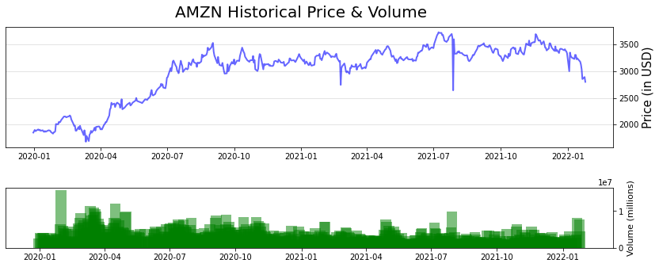

```python
adj_close_price_volume_plot(AMZN_close_volume)
```

## 3. Create a function that calculates the Return of Investment (ROI) (1 point)

Let's suppose you buy one stock one day, you hold it for N days (lookback period) and after N days you sell it.

$$ ROI = \frac{FVI - IVI}{IVI} * 100$$

- IVI: initial value of investment. This is the price at which you bought the stock
- FVI: final value of investment. This is the price at which you sold the stock
- ROI: Return of Investment. This is the percentage of increase in value of the investment

Now that we know how to calculate the ROI, create a function in Python that receives as parameters the following:

- lookback: the number of days you hold the stock
- name: the name of the stock, using the "Close" value of the stock
- data: the dataframe with the stock data

```python
#ROI function

#creating separate dataframes so the function can work its magic more easily
#I'm gonna keep the ticker column as well

GOOG_close = stox_complete_sorted[['adj close GOOG']]
GOOG_close['ticker'] = 'GOOG'
GOOG_close.columns = GOOG_close.columns.str.replace("adj close GOOG","adj close")

AMZN_close = stox_complete_sorted[['adj close AMZN']]
AMZN_close['ticker'] = 'AMZN'
AMZN_close.columns = AMZN_close.columns.str.replace("adj close AMZN","adj close")

MSFT_close = stox_complete_sorted[['adj close MSFT']]
MSFT_close.columns = MSFT_close.columns.str.replace("adj close MSFT","adj close")
MSFT_close['ticker'] = 'MSFT'

AAPL_close = stox_complete_sorted[['adj close AAPL']]
AAPL_close.columns = AAPL_close.columns.str.replace("adj close AAPL","adj close")
AAPL_close['ticker'] = 'AAPL'
```

```python
#checking if the column with the ticker was created correctly
AMZN_close.head()
```

| date | adj close | ticker |
| --- | --- | --- |
| 2019-12-31 | 1847.839966 | AMZN |
| 2020-01-02 | 1898.010010 | AMZN |
| 2020-01-03 | 1874.969971 | AMZN |
| 2020-01-06 | 1902.880005 | AMZN |
| 2020-01-07 | 1906.859985 | AMZN |

```python
#setting a function for calculating ROI for each stock and for different time frames

def ROI_calculation(dataframe, lookback):

    if lookback == '365 days':
        lookback = 365
        close = dataframe['adj close']
        ROI_df = pd.DataFrame(100 * (close / close.shift(lookback) - 1))

    elif lookback == '180 days':
        lookback = 180
        close = dataframe['adj close']
        ROI_df = pd.DataFrame(100 * (close / close.shift(lookback) - 1))

    elif lookback == '90 days':
        lookback = 90
        close = dataframe['adj close']
        ROI_df = pd.DataFrame(100 * (close / close.shift(lookback) - 1))

    return ROI_df
```

## 4. Apply the roi function to the portfolio (1.5 point)

Create as many ROI columns as different stocks you have in the portfolio and plot them in a 2x2 grid, representing for each stock:

- ROI after holding the stock for 365 days (red, dashed line) (0.5 points)
- ROI after holding the stock for 180 days (blue, dotted line) (0.5 points)
- ROI after holding the stock for 90 days (green, solid line) (0.5 points)

```python
#using the function to store one year ROI calculations for each stock
one_year_ROI_GOOG = ROI_calculation(GOOG_close, '365 days')
one_year_ROI_AMZN = ROI_calculation(AMZN_close, '365 days')
one_year_ROI_MSFT = ROI_calculation(MSFT_close, '365 days')
one_year_ROI_AAPL = ROI_calculation(AAPL_close, '365 days')

#using the function to store 180d days ROI calculations for each stock
ROI_180_days_GOOG = ROI_calculation(GOOG_close, '180 days')
ROI_180_days_AMZN = ROI_calculation(AMZN_close, '180 days')
ROI_180_days_MSFT = ROI_calculation(MSFT_close, '180 days')
ROI_180_days_AAPL = ROI_calculation(AAPL_close, '180 days')

#using the function to store 90 days ROI calculations for each stock
ROI_90_days_GOOG = ROI_calculation(GOOG_close, '90 days')
ROI_90_days_AMZN = ROI_calculation(AMZN_close, '90 days')
ROI_90_days_MSFT = ROI_calculation(MSFT_close, '90 days')
ROI_90_days_AAPL = ROI_calculation(AAPL_close, '90 days')
```

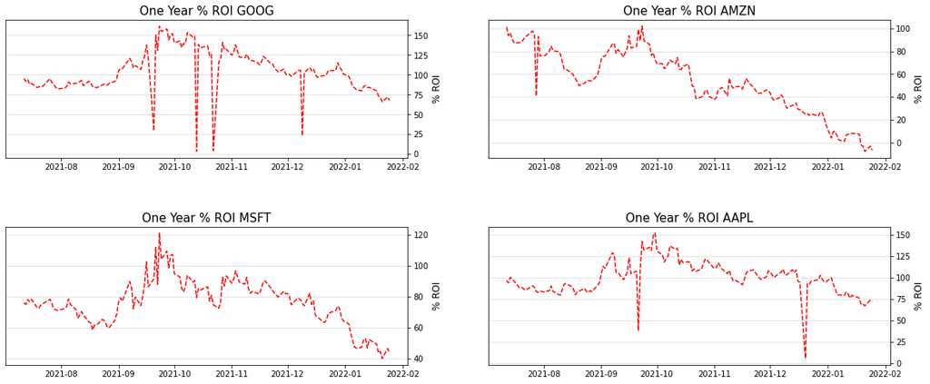

```python
#plotting one year ROI for each stocks

fig, axes = plt.subplots(2, 2, figsize=(20, 8))
plt.subplots_adjust(hspace=0.5)

axes[0,0].plot(one_year_ROI_GOOG.index, one_year_ROI_GOOG,label="one year % ROI GOOG", color='r', linestyle = "--")
axes[0,0].set_title('One Year % ROI GOOG', fontsize=15)
axes[0,0].set_ylabel('% ROI', fontsize=12)
axes[0,0].yaxis.set_label_position("right")
axes[0,0].yaxis.tick_right()
axes[0,0].grid(axis='y', color='gainsboro')

axes[0,1].plot(one_year_ROI_AMZN.index, one_year_ROI_AMZN,label="one year % ROI AMZN", color='r', linestyle = "--")
axes[0,1].set_title('One Year % ROI AMZN', fontsize=15)
axes[0,1].set_ylabel('% ROI', fontsize=12)
axes[0,1].yaxis.set_label_position("right")
axes[0,1].yaxis.tick_right()
axes[0,1].grid(axis='y', color='gainsboro')

axes[1,0].plot(one_year_ROI_MSFT.index, one_year_ROI_MSFT,label="one year % ROI MSFT", color='r', linestyle = "--")
axes[1,0].set_title('One Year % ROI MSFT', fontsize=15)
axes[1,0].set_ylabel('% ROI', fontsize=12)
axes[1,0].yaxis.set_label_position("right")
axes[1,0].yaxis.tick_right()
axes[1,0].grid(axis='y', color='gainsboro')

axes[1,1].plot(one_year_ROI_AAPL.index, one_year_ROI_AAPL,label="one year % ROI AAPL", color='r', linestyle = "--")
axes[1,1].set_title('One Year % ROI AAPL', fontsize=15)
axes[1,1].set_ylabel('% ROI', fontsize=12)
axes[1,1].yaxis.set_label_position("right")
axes[1,1].yaxis.tick_right()
axes[1,1].grid(axis='y', color='gainsboro')
```

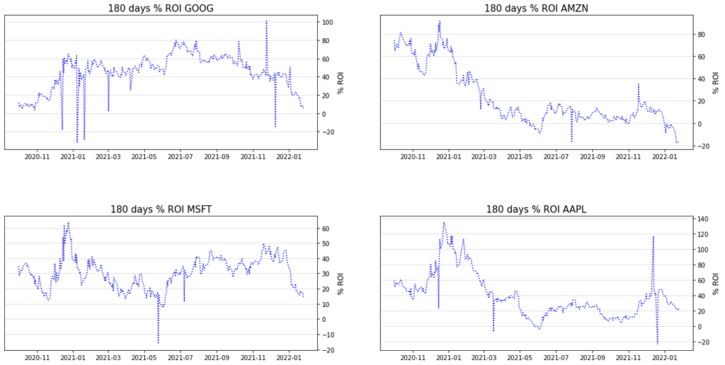

```python
fig, axes = plt.subplots(2, 2, figsize=(20, 10))
plt.subplots_adjust(hspace=0.5)

axes[0,0].plot(ROI_180_days_GOOG.index, ROI_180_days_GOOG,label="one year % ROI GOOG", color='b', linestyle = ":")
axes[0,0].set_title('180 days % ROI GOOG', fontsize=15)
axes[0,0].set_ylabel('% ROI', fontsize=12)
axes[0,0].yaxis.set_label_position("right")
axes[0,0].yaxis.tick_right()
axes[0,0].grid(axis='y', color='gainsboro')


axes[0,1].plot(ROI_180_days_AMZN.index, ROI_180_days_AMZN,label="180 days % ROI AMZN", color='b', linestyle = ":")
axes[0,1].set_title('180 days % ROI AMZN', fontsize=15)
axes[0,1].set_ylabel('% ROI', fontsize=12)
axes[0,1].yaxis.set_label_position("right")
axes[0,1].yaxis.tick_right()
axes[0,1].grid(axis='y', color='gainsboro')

axes[1,0].plot(ROI_180_days_MSFT.index, ROI_180_days_MSFT,label="180 days % ROI MSFT", color='b', linestyle = ":")
axes[1,0].set_title('180 days % ROI MSFT', fontsize=15)
axes[1,0].set_ylabel('% ROI', fontsize=12)
axes[1,0].yaxis.set_label_position("right")
axes[1,0].yaxis.tick_right()
axes[1,0].grid(axis='y', color='gainsboro')

axes[1,1].plot(ROI_180_days_AAPL.index, ROI_180_days_AAPL,label="180 days % ROI AAPL", color='b', linestyle = ":")
axes[1,1].set_title('180 days % ROI AAPL', fontsize=15)
axes[1,1].set_ylabel('% ROI', fontsize=12)
axes[1,1].yaxis.set_label_position("right")
axes[1,1].yaxis.tick_right()
axes[1,1].grid(axis='y', color='gainsboro')
```

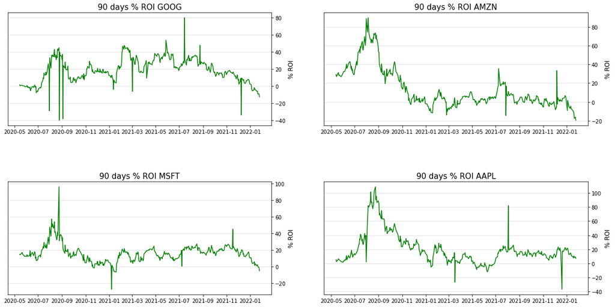

```python
fig, axes = plt.subplots(2, 2, figsize=(20, 10))
plt.subplots_adjust(hspace=0.5)

axes[0,0].plot(ROI_90_days_GOOG.index, ROI_90_days_GOOG,label="90 days % ROI GOOG", color='g')
axes[0,0].set_title('90 days % ROI GOOG', fontsize=15)
axes[0,0].set_ylabel('% ROI', fontsize=12)
axes[0,0].yaxis.set_label_position("right")
axes[0,0].yaxis.tick_right()
axes[0,0].grid(axis='y', color='gainsboro')


axes[0,1].plot(ROI_90_days_AMZN.index, ROI_90_days_AMZN,label="90 days % ROI AMZN", color='g')
axes[0,1].set_title('90 days % ROI AMZN', fontsize=15)
axes[0,1].set_ylabel('% ROI', fontsize=12)
axes[0,1].yaxis.set_label_position("right")
axes[0,1].yaxis.tick_right()
axes[0,1].grid(axis='y', color='gainsboro')

axes[1,0].plot(ROI_90_days_MSFT.index, ROI_90_days_MSFT,label="90 days % ROI MSFT", color='g')
axes[1,0].set_title('90 days % ROI MSFT', fontsize=15)
axes[1,0].set_ylabel('% ROI', fontsize=12)
axes[1,0].yaxis.set_label_position("right")
axes[1,0].yaxis.tick_right()
axes[1,0].grid(axis='y', color='gainsboro')

axes[1,1].plot(ROI_90_days_AAPL.index, ROI_90_days_AAPL,label="90 days % ROI AAPL", color='g')
axes[1,1].set_title('90 days % ROI AAPL', fontsize=15)
axes[1,1].set_ylabel('% ROI', fontsize=12)
axes[1,1].yaxis.set_label_position("right")
axes[1,1].yaxis.tick_right()
axes[1,1].grid(axis='y', color='gainsboro')
```

## 5. Optimizing portfolio (1 point)

Given these two portfolios, which one has the best ROI? Keep in mind that ROI is a percentage and you can't average it directly -- you need to convert the ROI to a return in currency by multiplying it by the buy price, and then average that over the period.

- Portfolio 1:
  - AAPL 40%
  - GOOG 30%
  - MSFT 20%
  - AMZN 10%
- Portfolio 2:
  - AAPL 30%
  - GOOG 20%
  - MSFT 10%
  - AMZN 40%

```python
# DF to store closing price and ROI 365 days for each stock
GOOG_returns_365_days = pd.merge(GOOG_close, one_year_ROI_GOOG, on=['date'])

GOOG_returns_365_days.columns = GOOG_returns_365_days.columns.str.replace( #changing column names
                       "adj close_x","adj close").str.replace(
                       "adj close_y","365 days % ROI")

#column operations to calculate total returns per lookback timeframe
AMZN_returns_365_days = pd.merge(AMZN_close, one_year_ROI_AMZN, on=['date'])
AMZN_returns_365_days.columns = GOOG_returns_365_days.columns.str.replace( #changing column names
                       "adj close_x","adj close").str.replace(
                       "adj close_y","365 days % ROI")

MSFT_returns_365_days = pd.merge(MSFT_close, one_year_ROI_MSFT, on=['date'])
MSFT_returns_365_days.columns = MSFT_returns_365_days.columns.str.replace( #changing column names
                       "adj close_x","adj close").str.replace(
                       "adj close_y","365 days % ROI")

AAPL_returns_365_days = pd.merge(AAPL_close, one_year_ROI_AAPL, on=['date'])
AAPL_returns_365_days.columns = AAPL_returns_365_days.columns.str.replace( #changing column names
                       "adj close_x","adj close").str.replace(
                       "adj close_y","365 days % ROI")

#creating a new column with the return value in $ for each stock for 365 days
GOOG_returns_365_days["365 days returns"] = GOOG_returns_365_days["adj close"] * GOOG_returns_365_days["365 days % ROI"]
AMZN_returns_365_days["365 days returns"] = AMZN_returns_365_days["adj close"] * AMZN_returns_365_days["365 days % ROI"]
MSFT_returns_365_days["365 days returns"] = MSFT_returns_365_days["adj close"] * MSFT_returns_365_days["365 days % ROI"]
AAPL_returns_365_days["365 days returns"] = AAPL_returns_365_days["adj close"] * AAPL_returns_365_days["365 days % ROI"]
```

```python
# DF to store closing price and ROI 180 days for each stock
GOOG_returns_180_days = pd.merge(GOOG_close, ROI_180_days_GOOG, on=['date'])
GOOG_returns_180_days.columns = GOOG_returns_180_days.columns.str.replace( #changing column names
                       "adj close_x","adj close").str.replace(
                       "adj close_y","180 days % ROI")

#column operations to calculate total returns per lookback timeframe
AMZN_returns_180_days = pd.merge(AMZN_close, ROI_180_days_AMZN, on=['date'])
AMZN_returns_180_days.columns = AMZN_returns_180_days.columns.str.replace( #changing column names
                       "adj close_x","adj close").str.replace(
                       "adj close_y","180 days % ROI")

MSFT_returns_180_days = pd.merge(MSFT_close, ROI_180_days_MSFT, on=['date'])
MSFT_returns_180_days.columns = MSFT_returns_180_days.columns.str.replace( #changing column names
                       "adj close_x","adj close").str.replace(
                       "adj close_y","180 days % ROI")

AAPL_returns_180_days = pd.merge(AAPL_close, ROI_180_days_AAPL, on=['date'])
AAPL_returns_180_days.columns = AAPL_returns_180_days.columns.str.replace( #changing column names
                       "adj close_x","adj close").str.replace(
                       "adj close_y","180 days % ROI")

#creating a new column with the return value in $ for each stock for 180 days
GOOG_returns_180_days["180 days returns"] = GOOG_returns_180_days["adj close"] * GOOG_returns_180_days["180 days % ROI"]
AMZN_returns_180_days["180 days returns"] = AMZN_returns_180_days["adj close"] * AMZN_returns_180_days["180 days % ROI"]
MSFT_returns_180_days["180 days returns"] = MSFT_returns_180_days["adj close"] * MSFT_returns_180_days["180 days % ROI"]
AAPL_returns_180_days["180 days returns"] = AAPL_returns_180_days["adj close"] * AAPL_returns_180_days["180 days % ROI"]
```

```python
GOOG_returns_90_days = pd.merge(GOOG_close, ROI_90_days_GOOG, on=['date'])
GOOG_returns_90_days.columns = GOOG_returns_90_days.columns.str.replace( #changing column names
                       "adj close_x","adj close").str.replace(
                       "adj close_y","90 days % ROI")

AMZN_returns_90_days = pd.merge(AMZN_close, ROI_90_days_AMZN, on=['date'])
AMZN_returns_90_days.columns = AMZN_returns_90_days.columns.str.replace( #changing column names
                       "adj close_x","adj close").str.replace(
                       "adj close_y","90 days % ROI")

MSFT_returns_90_days = pd.merge(MSFT_close, ROI_90_days_MSFT, on=['date'])
MSFT_returns_90_days.columns = MSFT_returns_90_days.columns.str.replace( #changing column names
                       "adj close_x","adj close").str.replace(
                       "adj close_y","90 days % ROI")

AAPL_returns_90_days = pd.merge(AAPL_close, ROI_90_days_AAPL, on=['date'])
AAPL_returns_90_days.columns = AAPL_returns_90_days.columns.str.replace( #changing column names
                       "adj close_x","adj close").str.replace(
                       "adj close_y","90 days % ROI")

GOOG_returns_90_days["90 days returns"] = GOOG_returns_90_days["adj close"] * GOOG_returns_90_days["90 days % ROI"]
AMZN_returns_90_days["90 days returns"] = AMZN_returns_90_days["adj close"] * AMZN_returns_90_days["90 days % ROI"]
MSFT_returns_90_days["90 days returns"] = MSFT_returns_90_days["adj close"] * MSFT_returns_90_days["90 days % ROI"]
AAPL_returns_90_days["90 days returns"] = AAPL_returns_90_days["adj close"] * AAPL_returns_90_days["90 days % ROI"]
```

```python
# creating individual dataframes for the ROI calculations of each stock
    # I did this in order for the function to work smoothly

ROI_GOOG_merged = pd.concat([GOOG_returns_90_days,GOOG_returns_180_days,GOOG_returns_365_days], axis=1)
ROI_GOOG_merged = ROI_GOOG_merged.loc[:,~ROI_GOOG_merged.columns.duplicated()] #removing duplicates

ROI_AMZN_merged = pd.concat([AMZN_returns_90_days,AMZN_returns_180_days,AMZN_returns_365_days], axis=1)
ROI_AMZN_merged = ROI_AMZN_merged.loc[:,~ROI_AMZN_merged.columns.duplicated()] #removing duplicates

ROI_AAPL_merged = pd.concat([AAPL_returns_90_days,AAPL_returns_180_days,AAPL_returns_365_days], axis=1)
ROI_APPL_merged = ROI_AAPL_merged.loc[:,~ROI_AAPL_merged.columns.duplicated()] #removing duplicates


ROI_MSFT_merged = pd.concat([MSFT_returns_90_days,MSFT_returns_180_days,MSFT_returns_365_days], axis=1)
ROI_MSFT_merged = ROI_MSFT_merged.loc[:,~ROI_MSFT_merged.columns.duplicated()] #removing duplicates
```

```python
#checking if the dfs merged correctly
ROI_GOOG_merged.tail()
```

| date | adj close | ticker | 90 days % ROI | 90 days returns | 180 days % ROI | 180 days returns | 365 days % ROI | 365 days returns |
| --- | --- | --- | --- | --- | --- | --- | --- | --- |
| 2022-01-19 | 2713.040039 | GOOG | -6.391053 | -17339.183377 | 17.594226 | 47733.838932 | 73.277476 | 198804.725067 |
| 2022-01-20 | 2670.129883 | GOOG | -5.929004 | -15831.211542 | 12.194578 | 32561.107142 | 71.335699 | 190475.582838 |
| 2022-01-21 | 2601.840088 | GOOG | -9.321436 | -24252.885248 | 7.076460 | 18411.818274 | 65.881842 | 171414.017663 |
| 2022-01-24 | 2607.439941 | GOOG | -9.088886 | -23698.725105 | 8.187137 | 21347.466760 | 72.031026 | 187816.573203 |
| 2022-01-25 | 2534.709961 | GOOG | -12.720209 | -32242.041132 | 5.825893 | 14766.949256 | 67.653963 | 171483.173698 |

```python
# i could not create a function to use with a fully merged ROI dataset
# I can create one that works with single dataframes, this was my best attempt

def portfolio_return_calculator(dataframe, percentage, timeframe):
    if percentage == 90:
        percentage = 0.9
        if timeframe == 365:
            returns = (dataframe['365 days returns'].mean())*percentage
        elif timeframe == 180:
            returns = (dataframe['180 days returns'].mean())*percentage
        elif timeframe == 90:
            returns = (dataframe['90 days returns'].mean())*percentage

    elif percentage == 80:
        percentage = 0.8
        if timeframe == 365:
            returns = (dataframe['365 days returns'].mean())*percentage
        elif timeframe == 180:
            returns = (dataframe['180 days returns'].mean())*percentage
        elif timeframe == 90:
            returns = (dataframe['90 days returns'].mean())*percentage

    elif percentage == 70:
        percentage = 0.7
        if timeframe == 365:
            returns = (dataframe['365 days returns'].mean())*percentage
        elif timeframe == 180:
            returns = (dataframe['180 days returns'].mean())*percentage
        elif timeframe == 90:
            returns = (dataframe['90 days returns'].mean())*percentage

    elif percentage == 60:
        percentage = 0.6
        if timeframe == 365:
            returns = (dataframe['365 days returns'].mean())*percentage
        elif timeframe == 180:
            returns = (dataframe['180 days returns'].mean())*percentage
        elif timeframe == 90:
            returns = (dataframe['90 days returns'].mean())*percentage

    elif percentage == 50:
        percentage = 0.5
        if timeframe == 365:
            returns = (dataframe['365 days returns'].mean())*percentage
        elif timeframe == 180:
            returns = (dataframe['180 days returns'].mean())*percentage
        elif timeframe == 90:
            returns = (dataframe['90 days returns'].mean())*percentage

    elif percentage == 40:
        percentage = 0.40
        if timeframe == 365:
            returns = (dataframe['365 days returns'].mean())*percentage
        elif timeframe == 180:
            returns = (dataframe['180 days returns'].mean())*percentage
        elif timeframe == 90:
            returns = (dataframe['90 days returns'].mean())*percentage

    elif percentage == 30:
        percentage = 0.30
        if timeframe == 365:
            returns = (dataframe['365 days returns'].mean())*percentage
        elif timeframe == 180:
            returns = (dataframe['180 days returns'].mean())*percentage
        elif timeframe == 90:
            returns = (dataframe['90 days returns'].mean())*percentage

    elif percentage == 20:
        percentage = 0.20
        if timeframe == 365:
            returns = (dataframe['365 days returns'].mean())*percentage
        elif timeframe == 180:
            returns = (dataframe['180 days returns'].mean())*percentage
        elif timeframe == 90:
            returns = (dataframe['90 days returns'].mean())*percentage

    elif percentage == 10:
        percentage = 0.10
        if timeframe == 365:
            returns = (dataframe['365 days returns'].mean())*percentage
        elif timeframe == 180:
            returns = (dataframe['180 days returns'].mean())*percentage
        elif timeframe == 90:
            returns = (dataframe['90 days returns'].mean())*percentage

    return returns
```

## Now that we have the function ready let's calculate the average returns per portfolio and per timeframe :-)

## Porfolio Combination #1

```python
portfolio_1_365_days_avg_returns =portfolio_return_calculator(
    ROI_GOOG_merged,20, 365) + portfolio_return_calculator(
    ROI_AMZN_merged,10, 365) + portfolio_return_calculator(
    ROI_MSFT_merged,20, 365) + portfolio_return_calculator(
    ROI_AAPL_merged,40, 365)

f'Portfolio 1 yields an average of ${round(portfolio_1_365_days_avg_returns,2)} in returns if positions are held for 365 days'
```

```
'Portfolio 1 yields an average of $88613.55 in returns if positions are held for 365 days'
```

```python
portfolio_1_180_days_avg_returns =portfolio_return_calculator(
    ROI_GOOG_merged,20, 180) + portfolio_return_calculator(
    ROI_AMZN_merged,10, 180) + portfolio_return_calculator(
    ROI_MSFT_merged,20, 180) + portfolio_return_calculator(
    ROI_AAPL_merged,40, 180)

f'Portfolio 1 yields an average of ${round(portfolio_1_180_days_avg_returns,2)} in returns if positions are held for 180 days'
```

```
'Portfolio 1 yields an average of $33291.75 in returns if positions are held for 180 days'
```

```python
portfolio_1_90_days_avg_returns =portfolio_return_calculator(
    ROI_GOOG_merged,20, 90) + portfolio_return_calculator(
    ROI_AMZN_merged,10, 90) + portfolio_return_calculator(
    ROI_MSFT_merged,20, 90) + portfolio_return_calculator(
    ROI_AAPL_merged,40, 90)

f'Portfolio 1 yields an average of ${round(portfolio_1_90_days_avg_returns,2)} in returns if positions are held for 90 days'
```

```
'Portfolio 1 yields an average of $14394.62 in returns if positions are held for 90 days'
```

## Portfolio combination #2

```python
portfolio_2_365_days_avg_returns =portfolio_return_calculator(
    ROI_GOOG_merged,20, 365) + portfolio_return_calculator(
    ROI_AMZN_merged,40, 365) + portfolio_return_calculator(
    ROI_MSFT_merged,10, 365) + portfolio_return_calculator(
    ROI_AAPL_merged,30, 365)

f'Portfolio 1 yields an average of ${round(portfolio_2_365_days_avg_returns,2)} in returns if positions are held for 365 days'
```

```
'Portfolio 1 yields an average of $139835.73 in returns if positions are held for 365 days'
```

```python
portfolio_2_180_days_avg_returns =portfolio_return_calculator(
    ROI_GOOG_merged,20, 180) + portfolio_return_calculator(
    ROI_AMZN_merged,40, 180) + portfolio_return_calculator(
    ROI_MSFT_merged,10, 180) + portfolio_return_calculator(
    ROI_AAPL_merged,30, 180)

f'Portfolio 1 yields an average of ${round(portfolio_2_180_days_avg_returns,2)} in returns if positions are held for 180 days'
```

```
'Portfolio 1 yields an average of $53520.05 in returns if positions are held for 180 days'
```

```python
portfolio_2_90_days_avg_returns = portfolio_return_calculator(
    ROI_GOOG_merged,20, 90) + portfolio_return_calculator(
    ROI_AMZN_merged,40, 90) + portfolio_return_calculator(
    ROI_MSFT_merged,10, 90) + portfolio_return_calculator(
    ROI_AAPL_merged,30, 90)

f'Portfolio 1 yields an average of ${round(portfolio_2_90_days_avg_returns,2)} in returns if positions are held for 90 days'
```

```
'Portfolio 1 yields an average of $26405.63 in returns if positions are held for 90 days'
```

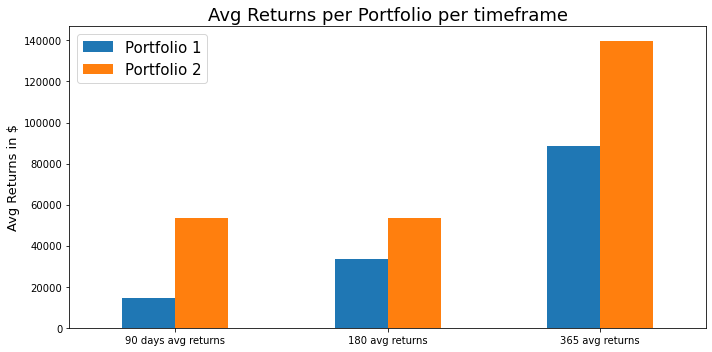

```python
#plotting the avg returns per portfolio per timeframe

returns_df = pd.DataFrame({
    "Portfolio 1":[portfolio_1_90_days_avg_returns, portfolio_1_180_days_avg_returns,portfolio_1_365_days_avg_returns],
    "Portfolio 2":[portfolio_2_180_days_avg_returns, portfolio_2_180_days_avg_returns,portfolio_2_365_days_avg_returns],
},
    index = ['90 days avg returns',"180 avg returns", "365 avg returns"]
)

returns_df.plot(kind = "bar", figsize=(10,5))
plt.title("Avg Returns per Portfolio per timeframe", fontsize = 18)
plt.xticks(rotation='horizontal')
plt.ylabel('Avg Returns in $', fontsize=13)
plt.legend(fontsize=15)
plt.tight_layout()
```

## 6. Find a better combination in your portfolio (1 point)

The new combination should beat the best portfolio that you found in the previous exercise.

```python
# I tried to think about an ingenious way to iterate through many combinations but I just couldn't

    # decided to set a function that tells me wether the combination is better or not
    # let's take the best perfoming portfolio for 365 days, which was portfolio 2, for comparison

def avg_return_comparison_365_days(portfolio):
    if portfolio > portfolio_2_365_days_avg_returns:
        change_percentage = 100*(portfolio_test_365_days_avg_returns-portfolio_2_365_days_avg_returns)/portfolio_2_365_days_avg_returns
        message = f'This portfolio combination yields {round(change_percentage,2)}% more avg returns than portfolio 2 if positions are held for 365 days'

    else:
        change_percentage = -100*(portfolio_test_365_days_avg_returns-portfolio_2_365_days_avg_returns)/portfolio_2_365_days_avg_returns
        message = f'This portfolio combination yields {round(change_percentage,2)}% less returns than portfolio 2 if positions are held for 365 days'

    return message
```

```python
#for 365 days
    #10% GOOG
    #60% AMZN
    #10% MSFT
    #20 AAPL
    # this combo yields a higher avg return than the original combo

portfolio_test_365_days_avg_returns =portfolio_return_calculator(
    ROI_GOOG_merged,10, 365) + portfolio_return_calculator(
    ROI_AMZN_merged,60, 365) + portfolio_return_calculator(
    ROI_MSFT_merged,10, 365) + portfolio_return_calculator(
    ROI_AAPL_merged,20, 365)

avg_return_comparison_365_days(portfolio_test_365_days_avg_returns)
```

```
'This portfolio combination yields 3.96% more avg returns than portfolio 2 if positions are held for 365 days'
```

```python
#for 365 days
    #40% GOOG
    #20% AMZN
    #20% MSFT
    #20 AAPL
    # this combo yields a higher avg return than the original combo

portfolio_test_365_days_avg_returns =portfolio_return_calculator(
    ROI_GOOG_merged,40, 365) + portfolio_return_calculator(
    ROI_AMZN_merged,20, 365) + portfolio_return_calculator(
    ROI_MSFT_merged,20, 365) + portfolio_return_calculator(
    ROI_AAPL_merged,20, 365)

avg_return_comparison_365_days(portfolio_test_365_days_avg_returns)
```

```
'This portfolio combination yields 16.73% more avg returns than portfolio 2 if positions are held for 365 days'
```

```python
#for 365 days
    #20% GOOG
    #50% AMZN
    #10% MSFT
    #20% AAPL
    # this combo yields a higher avg return than the original combo

portfolio_test_365_days_avg_returns =portfolio_return_calculator(
    ROI_GOOG_merged,20, 365) + portfolio_return_calculator(
    ROI_AMZN_merged,50, 365) + portfolio_return_calculator(
    ROI_MSFT_merged,10, 365) + portfolio_return_calculator(
    ROI_AAPL_merged,20, 365)

avg_return_comparison_365_days(portfolio_test_365_days_avg_returns)
```

```
'This portfolio combination yields 12.03% more avg returns than portfolio 2 if positions are held for 365 days'
```

```python
#for 365 days
    #30% GOOG
    #30% AMZN
    #30% MSFT
    #10% AAPL
    # this combo yields a higher avg return than the original combo

portfolio_test_365_days_avg_returns =portfolio_return_calculator(
    ROI_GOOG_merged,30, 365) + portfolio_return_calculator(
    ROI_AMZN_merged,30, 365) + portfolio_return_calculator(
    ROI_MSFT_merged,30, 365) + portfolio_return_calculator(
    ROI_AAPL_merged,10, 365)

avg_return_comparison_365_days(portfolio_test_365_days_avg_returns)
```

```
'This portfolio combination yields 9.23% more avg returns than portfolio 2 if positions are held for 365 days'
```